# Beyond the P-Value: Visualizing and Embracing Uncertainty

```r
packages = c("infer",
             "dplyr",
             "nullabor",
             "ggplot2")

## Figure out which packages are not installed and install them
installed = vapply(packages, function(x)
  length(find.package(x, quiet = TRUE)) > 0,
  TRUE)

if(any(!installed)) {
  install.packages(packages[!installed])
}

## Load packages
done = lapply(packages, require, character.only = TRUE)
```

## P-value: Living in the world of the null hypothesis

I tried to bend a quarter to make it “unfair” and yield tails more often. Did I succeed?

$$H_0: p = 0.5$$
$$H_A: p < 0.5$$

Let’s say I flip it 5 times and got heads only once. How unusual is that under the null hypothesis? We can easily simulate this in R using the `infer` package

```r
## Number of heads. Change this to see what happens!
number_heads = 1
n = 5
observed_p = number_heads/n

## Enter data
my_data = data.frame(flip = c(rep("T", n - number_heads),
                               rep("H", number_heads)))

null_flips = my_data %>%
  specify(response = flip, success = "T") %>%
  hypothesize("point", p = 0.5) %>%
  generate(reps = 1000, type = "simulate")
```

```r
head(null_flips, 15)
```

| flip | replicate |
| --- | --- |
| T | 1 |
| H | 1 |
| H | 1 |
| T | 1 |
| H | 1 |
| H | 2 |
| H | 2 |
| H | 2 |
| T | 2 |
| H | 2 |

[output cut: 5 more lines]

Then we calculate the number of heads per flip and plot the distribution of sets of flips, and see where one heads actually falls on that distribution.

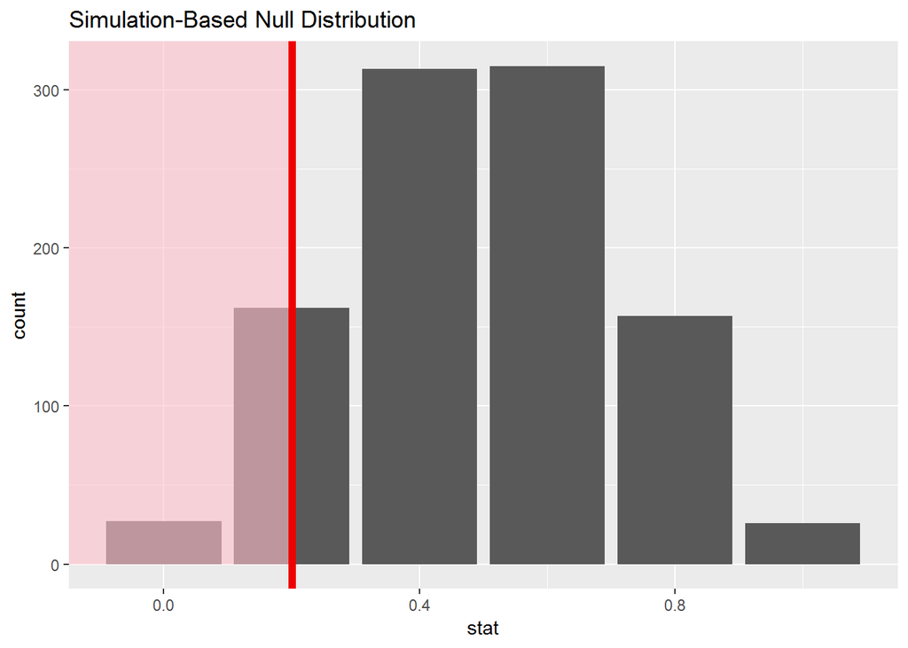

```r
null_proportions = null_flips %>%
  calculate(stat = "prop")

visualise(null_proportions) +
  shade_pvalue(observed_p, direction = "less")
```

The p-value is just the proportions of times we got one or fewer heads:

```r
null_proportions %>%
  get_pvalue(observed_p, direction = "less")
```

| p_value |
| --- |
| 0.189 |

## Experiment 1 data

`exp1.csv` contains 100 subjects who took the ESP test (tried to guess which curtain the picture was behind). During each session, some of the pictures were erotic and some were non-erotic.

Variables are as follows:

- *Session* Order in which participant was seen.
- *Session_Type* (Added EB) Some participants saw different combinations of stimuli. This is my best guess from Bem’s writing about which was which.
- *Num_Erotic* (Added EB) Number of erotic trials, varies by session type; my best guess.
- *Num_Control* (Added EB) Number of control trials, varies by session type; my best guess.
- *Erotic.Hits.PC* Percentage correct on erotic trials
- *Control.Hits.PC* Percentage correct on control trials
- *Stimulus.Seeking* 1-5 scale on how “stimulus-seeking” the participant is
- *Date*
- *StartTime*
- *Session.Length*
- *Participant.Sex*
- *Participant.Age*
- *ExpSex* ?

Below is code for reading in all trials, calculating the overall hit rate, and testing whether it is significantly different from chance:

$$H_0 = \mu_\text{hit rate} = 50$$
$$H_A = \mu_\text{hit rate} > 50$$
What did we actually see on average?

```r
# Original source: https://replicationindex.files.wordpress.com/2018/01/exp1.xlsx
# Some variables added as noted above.

exp1 = read.csv("exp1.csv", stringsAsFactors = FALSE)

exp1_all_hits = exp1 %>%
  mutate(All.Hits.PC = (Erotic.Hits.PC * Num_Erotic + Control.Hits.PC * Num_Control) * 100/(Num_Erotic + Num_Control))

all_hits_mean = exp1_all_hits %>%
    specify(response = All.Hits.PC) %>%
    calculate(stat = "mean")

all_hits_mean
```

| stat |
| --- |
| 5106.944 |

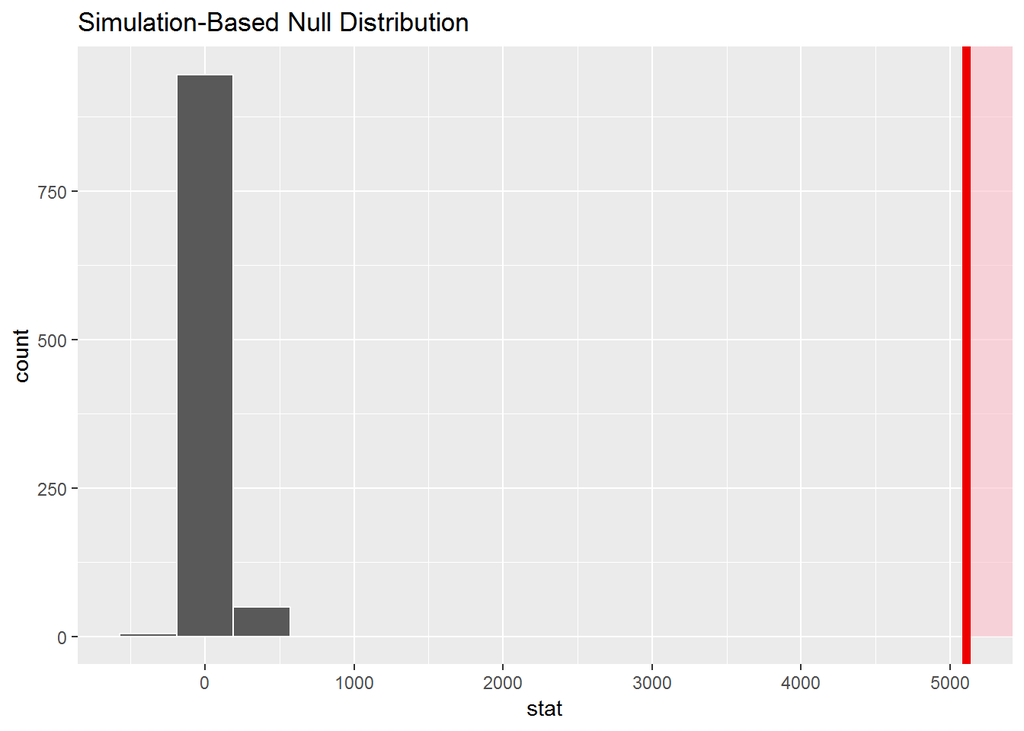

```r
null_all_hits = exp1_all_hits %>%
  specify(response = All.Hits.PC) %>%
  hypothesize(null = "point", mu = 50) %>%
  generate(reps = 1000, type = "bootstrap") %>%
  calculate(stat = "mean")

visualize(null_all_hits) +
  shade_pvalue(all_hits_mean, direction = "greater")
```

```r
null_all_hits %>%
  get_pvalue(all_hits_mean, direction = "greater")
```

| p_value |
| --- |
| 0 |

We can also do a good old-fashioned t-test, for a similar result:

```r
t.test(exp1_all_hits$All.Hits.PC, mu = 50, alternative = "greater")
```

```
##
##  One Sample t-test
##
## data:  exp1_all_hits$All.Hits.PC
## t = 60.923, df = 99, p-value < 2.2e-16
## alternative hypothesis: true mean is greater than 50
## 95 percent confidence interval:
##  4969.124      Inf
## sample estimates:
## mean of x
##  5106.944
```

Can you find any significant findings here?

## Visual hypothesis testing – the line-up

The dataset `mtcars`, included in R, contains the fuel consumption (`mpg`) and weight (`wt`) of 32 cars in 1974. See `?mtcars` for more information.

Here, our question is: is there any visible relationship between `mpg` and `wt`?

We can do a *visual hypothesis test*. We mix up `mpg` to break the relationship between `mpg` and `wt` using `lineup` from the *`nullabor`* package. (The example below is taken from the *`nullabor`* vignette.)

```r
d = lineup(null_permute("mpg"), mtcars)
```

```
## decrypt("qctY 2hNh ki F1EkNk1i 0A")
```

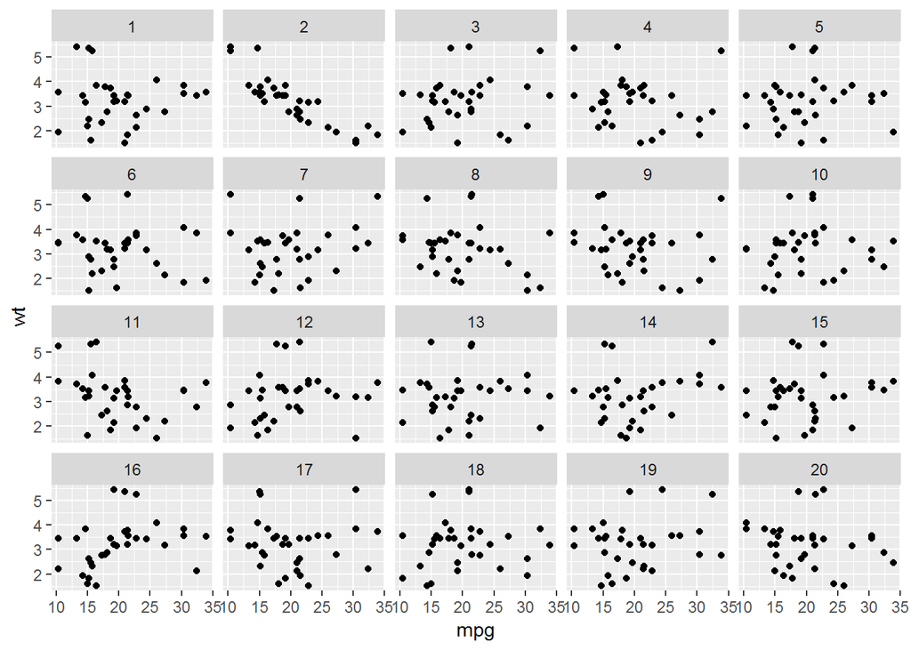

```r
ggplot(data=d, aes(x=mpg, y=wt)) +
  geom_point() +
  facet_wrap(~ .sample)
```

Can you tell which one is the real data?

We can reveal the position by accessing the `"pos"` attribute, using `attr(d, "pos")`. There are also features to hide the position from a user by using `encrypt()`!

If one person correctly guesses the correct value, then the visual p-value to reject the null hypothesis is 0.05 – they had a one in twenty chance of getting it correct. If you ask more than one person and they all get it correct, that increases your ability to get a low visual p-value. If 100 people are given the same 20 plots but only 15 get it correct, the p-value is still quite small:

```r
pvisual(15, 100, m = 20)
```

```
##       x simulated        binom
## [1,] 15    0.0083 0.0001358542
```

## Blinded analysis

We can take this idea a step further and do a *whole analysis* where somehow the true value has been blinded.

See `exp2_blinded.csv` for an example.

## Bayesian analysis

https://tellmi.psy.lmu.de/felix/BayesLessons/BayesianLesson1.Rmd

## Resources

We’re hear to help with any of this!

Research Methodology Consulting Center: cehd.umn.edu/research/consulting/

And our friends— LATIS: cla.umn.edu/latis IRSA: irsa.stat.umn.edu Libraries: libraries.umn.edu DASH: dash.umn.edu